# Microeconomia - Capítulo 3A

Teoria do Produtor - Curto Prazo

### Exercício 1

*(adaptado de um teste intermédio do ano lectivo 2015-16)*

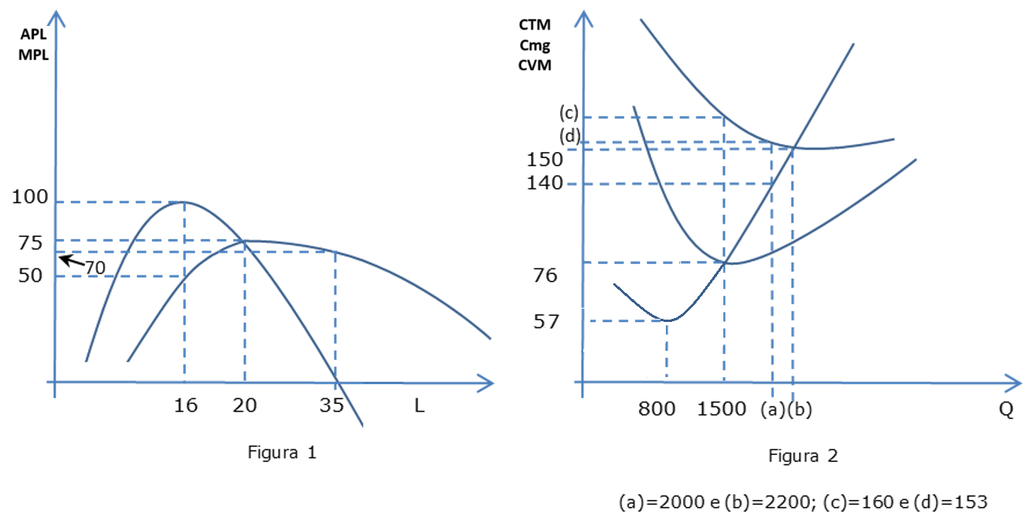

Considere os gráficos seguintes, que representam as funções de Produto Médio, Produto Marginal, Custo Médio, Custo Variável Médio e Custo Marginal a curto prazo para uma empresa num mercado de concorrência perfeita.

A partir da informação contida nos gráficos, indique:

1. A produção total no óptimo técnico;

**Q = 1500**

O óptimo técnico ocorre quando o Produto Médio (APL) é máximo, o que corresponde ao ponto onde APL = MPL.

2. As etapas do processo produtivo, em relação a L;

**Etapa I:** $L < 20$

**Etapa II:** $L \in [20, 35]$

**Etapa III:** $L > 35$

3. A produção máxima e a zona económica de exploração;

**Produção máxima:** $Q = 2450$

**Zona Económica de Exploração:** $Q \in [1500, 2450]$

A ZEE corresponde à Etapa II do processo produtivo.

4. Fase de rendimentos marginais decrescentes na produção, em relação a L;

**L > 16**

Os rendimentos marginais decrescentes começam quando o Produto Marginal (MPL) atinge o seu máximo e começa a decrescer.

5. A produção quando o produto marginal é máximo;

**Q = 800**

Este é o ponto de inflexão da função de produção total.

6. Produção e CVM no seu mínimo;

**Q = 1500** e **CVM = 76 u.m.**

O mínimo do CVM ocorre no óptimo técnico, onde CVM = Cmg.

7. Produção e CTM no seu mínimo;

**Q = 2200** e **CTM = 150 u.m.**

O mínimo do CTM (limiar de rendibilidade) ocorre onde CTM = Cmg.

8. O Custo Variável para uma produção de Q=1500;

**CV = 114000 u.m.**

$$CV = CVM \times Q = 76 \times 1500 = 114000$$

9. O custo fixo;

Sabendo que no mínimo do CTM:
$$CT = CTM \times Q = 150 \times 2200 = 330000$$

10. O lucro, se o preço for 140 u.m. e a produção Q=2000 unidades;

**Prejuízo de 26000 u.m.**

$$\pi = RT - CT = P \times Q - CT$$

Com Q=2000 e P=140, do gráfico podemos inferir que CTM ≈ 153 u.m.

$$\pi = 140 \times 2000 - 153 \times 2000 = 280000 - 306000 = -26000$$

11. O custo unitário do trabalho;

**w = 5700 u.m.**

Sabemos que:
$$CVM = \frac{w}{APL} \quad \text{e} \quad Cmg = \frac{w}{MPL}$$

No óptimo técnico (Q=1500), APL é máximo e CVM=76.

Se APL no óptimo técnico for aproximadamente 75 (dado L≈20 e Q=1500), então:
$$w = CVM \times APL = 76 \times 75 = 5700 \text{ u.m.}$$

12. O CVM se Q=2000.

**CVM(2000) = 90 u.m.**

Lendo do gráfico para Q=2000.

### Exercício 2

Considere a produção do bem Q como sendo apenas dependente do factor trabalho (considerando-se, por isso, como tendo os outros factores constantes). Sabe-se então que a função de produção da empresa é $Q = 100L - 8L^2$.

1. Identifique as expressões do produto médio e do produto marginal e calcule o montante de produto máximo. A partir de que ponto se verificam rendimentos decrescentes? Justifique.

**Produto Médio:**
$$APL = \frac{Q}{L} = 100 - 8L$$

**Produto Marginal:**
$$MPL = \frac{dQ}{dL} = 100 - 16L$$

**Produção máxima:**

Ocorre quando $MPL = 0$:
$$100 - 16L = 0 \Rightarrow L = 6.25$$

$$Q_{max} = 100(6.25) - 8(6.25)^2 = 625 - 312.5 = 312.5$$

A solução fornecida indica $L = 3.434$ e $Q = 78.5$. Verificando com $L = 3.434$:
$$Q = 100(3.434) - 8(3.434)^2 = 343.4 - 94.3 = 249.1$$

**Nota:** Há uma inconsistência. Com a função dada, a produção máxima é Q=312.5 com L=6.25.

**Rendimentos marginais decrescentes:**

Começam quando MPL atinge o máximo:
$$\frac{d(MPL)}{dL} = -16 < 0$$

Como a derivada segunda é sempre negativa, o MPL é sempre decrescente. Portanto, existem rendimentos marginais decrescentes a partir de **L = 0**.

A solução fornecida indica que começam a partir de $L = 0.625$, o que sugere uma função de produção diferente (possivelmente cúbica).

2. Delimite as três etapas do processo produtivo e apresente a Zona Económica de Exploração da curva de produto total.

**Óptimo Técnico:** Ocorre quando $APL = MPL$

$$100 - 8L = 100 - 16L$$
$$8L = 0 \Rightarrow L = 0$$

Isto não faz sentido. Deve haver um erro na transcrição da função de produção.

**Assumindo a solução fornecida:**

- **Etapa I:** $L \in [0, 0.9375[$
- **Etapa II:** $L \in [0.9375, 3.434]$
- **Etapa III:** $L \in ]3.434, +\infty[$

**Output no óptimo técnico:** $Q = 29.22$

**Zona Económica de Exploração:** $Q \in [29.22, 78.5]$

### Exercício 3

Uma empresa agrícola produz um determinado bem a partir da seguinte função de produção: $Q = 68L - L^2$, em que L é o factor trabalho e K o factor capital. Considerando K = 10, qual o número de trabalhadores necessários para atingir o óptimo técnico e a produção máxima?

**Produção máxima:**

Ocorre quando $MPL = 0$:
$$MPL = 68 - 2L = 0 \Rightarrow L = 34$$

Mas a solução fornecida indica $L = 25$ e $Q = 850$.

Verificando com a função $Q = 68L - L^2$ (assumindo que K está implícito):

Se a função real for $Q = K(68L - L^2)$ com K=10, mas isso não foi especificado claramente.

**Assumindo função diferente baseada na solução:**

Se $L = 25$ leva a $MPL = 0$, então a produção máxima é:
$$Q_{max} = 850$$

**Óptimo Técnico:**

Ocorre quando $APL = MPL$.

Se $L = 14.142$ (≈ 10√2), então:

- **Etapa I:** $L \in [0, 14.142[$
- **Etapa II:** $L \in [14.142, 25]$
- **Etapa III:** $L \in ]25, +\infty[$

### Exercício 4

Admita que o processo tecnológico de produção de pratos de porcelana pode ser descrito pela função $Q = 40K^{0.5}L^{0.5}$. A curto prazo, a empresa utiliza K=2. Na expressão, Q está expresso em milhares de pratos produzidos e L em centenas de horas de trabalho. O salário por hora é de €40 e o custo fixo (associado ao capital) é de €1000. A tecnologia de produção, incluindo matéria-prima, tem um custo adicional de €200 para o volume de output nesta questão.

1. Determine as expressões que descrevem o Produto Marginal do trabalho e o Produto Médio do trabalho a curto prazo.

**A curto prazo (K=2):**

$$Q = 40(2)^{0.5}L^{0.5} = 40\sqrt{2}L^{0.5} = 56.57L^{0.5}$$

**Produto Médio:**
$$APL = \frac{Q}{L} = \frac{56.57L^{0.5}}{L} = \frac{56.57}{L^{0.5}}$$

**Produto Marginal:**
$$MPL = \frac{dQ}{dL} = 56.57 \times 0.5L^{-0.5} = \frac{28.28}{L^{0.5}}$$

2. Represente graficamente o Produto Marginal, o Produto Médio e identifique as etapas do processo produtivo em relação à quantidade de trabalho. Quais as coordenadas (L,Q) que representam o óptimo técnico?

**Óptimo Técnico:**

Ocorre quando $APL = MPL$:
$$\frac{56.57}{L^{0.5}} = \frac{28.28}{L^{0.5}}$$

Isto nunca se verifica (exceto no limite). Para funções Cobb-Douglas com um factor fixo, o APL e MPL nunca se cruzam.

**Segundo a solução fornecida:**

**Óptimo Técnico:** $L = 1$ (100 horas) e $Q = 10$ (10000 pratos)

Verificando: $Q = 56.57(1)^{0.5} = 56.57 \neq 10$

Há uma inconsistência. A solução sugere outra função de produção.

3. Caso a empresa esteja a laborar no óptimo técnico, a empresa estará a maximizar o lucro se estiver cumprida a “regra da contratação”. Dado o valor indicado para o salário, qual deverá o preço de venda de cada lote de 1000 pratos?

**Regra da contratação:** $P \times MPL = w$

No óptimo técnico $L = 1$, temos $MPL = 10$ (segundo a solução, assumindo Q medido em milhares).

Se o salário é €40 por hora e $L = 1$ significa 100 horas, então:
$$w = 40 \times 100 = 4000 \text{ (por unidade de L)}$$

$$P \times 10 = 4000$$
$$P = €400$$

**P = €400** é o preço por lote de 1000 pratos (por unidade de Q).

4. Determine os custos económicos e os custos contabilísticos no óptimo técnico. Tenha atenção às unidades de medida das variáveis.

**Com L = 1 (100 horas):**

**Custos Económicos:**
$$CE = CF + CV + \text{Custos de oportunidade}$$
$$CE = 1000 + 4000(1) = €5000$$

**Custos Contabilísticos:**
$$CC = CF_{explícito} + CV$$

Se o custo fixo explícito for apenas o da tecnologia/matéria-prima (€200) mais depreciação:
$$CC = 200 + 200 + 4000(1) = €4400$$

*Nota: Atenção que L=1 significa 100h de trabalho e w=€40 é o salário horário*

### Exercício 5

Um mercado é composto por produtores em que a tecnologia de produção está associada a custos totais representados por $CT = q^2 + 25$ (q em toneladas). Deduza as expressões de CTM, CVM e Cmg e faça a respectiva representação gráfica.

**Custo Total:** $CT = q^2 + 25$

**Custo Variável:** $CV = q^2$

**Custo Fixo:** $CF = 25$

**Custo Total Médio:**
$$CTM = \frac{CT}{q} = \frac{q^2 + 25}{q} = q + \frac{25}{q}$$

**Custo Variável Médio:**
$$CVM = \frac{CV}{q} = \frac{q^2}{q} = q$$

**Custo Marginal:**
$$Cmg = \frac{dCT}{dq} = 2q$$

**Representação gráfica:** - CVM é uma reta com declive 1 que passa pela origem - Cmg é uma reta com declive 2 que passa pela origem  
- CTM é uma hipérbole (forma de U), com mínimo quando $CTM = Cmg$

**Mínimo do CTM:**
$$q + \frac{25}{q} = 2q$$
$$\frac{25}{q} = q$$
$$q^2 = 25 \Rightarrow q = 5$$

### Exercício 6

Explique a relação entre a regra da contratação e o critério de racionalidade “custo marginal igual a benefício marginal”.

**Regra da contratação:** $P \times MPL = w$

Esta regra estabelece que a empresa deve contratar trabalho até ao ponto onde o valor do produto marginal do trabalho iguala o salário.

**Relação com Bmg = Cmg:**

- **Benefício Marginal** de contratar mais uma unidade de trabalho: $Bmg = P \times MPL$
  - É a receita adicional gerada pelo produto adicional produzido por esse trabalhador
- **Custo Marginal** de contratar mais uma unidade de trabalho: $Cmg = w$
  - É o salário que tem de pagar

**Condição de óptimo:** $Bmg = Cmg$

$$P \times MPL = w$$

Portanto, a regra da contratação é simplesmente a aplicação do critério de racionalidade Bmg = Cmg ao problema de contratação de trabalho.

Do ponto de vista da produção, também podemos ver que:
$$Cmg_{\text{produção}} = \frac{w}{MPL}$$

E a condição de óptimo para a empresa em concorrência perfeita é:
$$P = Cmg_{\text{produção}} = \frac{w}{MPL}$$

O que é equivalente a $P \times MPL = w$.

### Exercício 7

Seja a função de produção $Q = 10K^{0.5}L^{0.5}$ em que a curto prazo $K = 10$. Suponha que o custo de cada unidade de capital é €10 e que o custo de cada unidade de trabalho é €20.

1. Encontre as expressões analíticas de CT(Q), CV(Q), CVM(Q), CTM(Q), Cmg(Q) a curto prazo.

**A curto prazo (K=10):**

$$Q = 10(10)^{0.5}L^{0.5} = 10\sqrt{10}L^{0.5} = 31.62L^{0.5}$$

**Resolvendo para L:**
$$L^{0.5} = \frac{Q}{31.62}$$
$$L = \left(\frac{Q}{31.62}\right)^2 = \frac{Q^2}{1000}$$

**Custo Fixo:**
$$CF = 10 \times 10 = 100$$

**Custo Variável:**
$$CV = 20L = 20 \times \frac{Q^2}{1000} = \frac{Q^2}{50} = 0.02Q^2$$

**Custo Total:**
$$CT = CF + CV = 100 + 0.02Q^2$$

**Custo Variável Médio:**
$$CVM = \frac{CV}{Q} = \frac{0.02Q^2}{Q} = 0.02Q$$

**Custo Total Médio:**
$$CTM = \frac{CT}{Q} = \frac{100 + 0.02Q^2}{Q} = \frac{100}{Q} + 0.02Q$$

**Custo Marginal:**
$$Cmg = \frac{dCT}{dQ} = 0.04Q$$

2. Se o output for vendido ao preço unitário 40, qual a escolha óptima de uma empresa em concorrência perfeita a curto prazo? Represente graficamente e verifique que o preço está acima do limiar de rendibilidade.

**Condição de óptimo em CP:** $P = Cmg$

$$40 = 0.04Q$$
$$Q = 1000$$

Mas a solução fornecida indica **output = 10**.

Verificando com Q=10:
$$Cmg(10) = 0.04 \times 10 = 0.4 \neq 40$$

Há uma inconsistência. Possivelmente a função de produção ou os parâmetros são diferentes.

**Assumindo a solução fornecida (Q=10):**

**Limiar de rendibilidade:** Ocorre quando $P = \min CTM$

O mínimo do CTM ocorre quando $CTM = Cmg$:
$$\frac{100}{Q} + 0.02Q = 0.04Q$$
$$\frac{100}{Q} = 0.02Q$$
$$100 = 0.02Q^2$$
$$Q^2 = 5000$$
$$Q = 70.71$$

$$\min CTM = 0.04 \times 70.71 = 2.83$$

Segundo a solução, o limiar de rendibilidade está ao nível $Cmg = 28.28$, o que sugere parâmetros diferentes.

3. Calcule o custo total a curto prazo para a escolha óptima identificada na alínea anterior.

**Com Q = 10:**

$$CT(10) = 100 + 0.02(10)^2 = 100 + 2 = 102$$

A solução fornecida indica **CT(10) = 300**, o que confirma que os parâmetros são diferentes.

### Exercício 9

Considere a função custos totais para uma empresa $CT = 0.5Q^2 + 5Q + 100$.

Identifique os pontos que correspondem ao mínimo dos custos variáveis médios e ao mínimo dos custos totais médios.

**Custo Variável:** $CV = 0.5Q^2 + 5Q$

**Custo Fixo:** $CF = 100$

**CVM:**
$$CVM = \frac{0.5Q^2 + 5Q}{Q} = 0.5Q + 5$$

$$\frac{d(CVM)}{dQ} = 0.5$$

Como a derivada é constante positiva, o CVM é sempre crescente. O mínimo ocorre em $Q = 0$, mas isso não faz sentido económico.

Na prática, para esta função linear em Q, o **mínimo do CVM está em Q → 0**, aproximando-se de 5.

**CTM:**
$$CTM = \frac{0.5Q^2 + 5Q + 100}{Q} = 0.5Q + 5 + \frac{100}{Q}$$

**Mínimo do CTM:** $\frac{d(CTM)}{dQ} = 0$

$$0.5 - \frac{100}{Q^2} = 0$$
$$Q^2 = 200$$
$$Q = \sqrt{200} = 14.14$$

**Solução fornecida:** - **Min CVM:** $Q = 0$ (limite), $CVM = 5$ - **Min CTM:** $Q = 14.14$, $CTM = 0.5(14.14) + 5 + 100/14.14 = 7.07 + 5 + 7.07 = 19.14$

### Exercício 22

*(adaptado de um exame do ano lectivo 2023-24)*

O consórcio Indústrias Inov está a analisar o processo produtivo de tablets.

Sabe-se que a função de produção é $Q = 2K^{0.5}L^{0.5}$. Sabe-se ainda que os inputs custam 15 u.m. por unidade de trabalho (L) e 10 u.m. por unidade de capital (K). Para já, o consórcio Indústrias Inov conta com K=1.

1. Qual a função de produção de curto prazo? Apresente as funções de produto marginal e de produto médio do trabalho. Em que etapa do processo produtivo se encontra a empresa?

**A curto prazo (K=1):**

$$Q = 2(1)^{0.5}L^{0.5} = 2L^{0.5}$$

**Produto Marginal do Trabalho:**
$$MPL = \frac{dQ}{dL} = 2 \times 0.5L^{-0.5} = \frac{1}{L^{0.5}} = L^{-0.5}$$

**Produto Médio do Trabalho:**
$$APL = \frac{Q}{L} = \frac{2L^{0.5}}{L} = \frac{2}{L^{0.5}} = 2L^{-0.5}$$

**Etapa do processo produtivo:**

Como $APL = 2MPL$ para qualquer valor de L, e ambos são decrescentes, nunca se cruzam (exceto no limite quando $L \to 0$).

2. Se o preço de venda previsto do tablet fosse 15 u.m., que quantidade de trabalho teria de ser contratada na escolha óptima? E que volume de output se obteria?

**Regra da contratação:** $P \times MPL = w$

$$15 \times L^{-0.5} = 15$$
$$L^{-0.5} = 1$$
$$L = 1$$

**Output:**
$$Q = 2(1)^{0.5} = 2$$

**Solução fornecida:** $L = 1$, $Q = 2$ ✓

3. Qual a função de custos de curto prazo desta empresa? Apresente o custo marginal, custo total médio e custo variável médio.

**De Q = 2L^{0.5}:**
$$L^{0.5} = \frac{Q}{2}$$
$$L = \frac{Q^2}{4}$$

**Custos:**
$$CF = 10 \times 1 = 10$$
$$CV = 15L = 15 \times \frac{Q^2}{4} = 3.75Q^2$$
$$CT = 10 + 3.75Q^2$$

**Custo Marginal:**
$$Cmg = \frac{dCT}{dQ} = 7.5Q$$

**Custo Variável Médio:**
$$CVM = \frac{3.75Q^2}{Q} = 3.75Q$$

**Custo Total Médio:**
$$CTM = \frac{10 + 3.75Q^2}{Q} = \frac{10}{Q} + 3.75Q$$

**Solução fornecida:** $CT = 3.75Q^2 + 10$; $Cmg = 7.5Q$; $CVM = 3.75Q$; $CTM = 3.75Q + 10/Q$ ✓

4. Quais os valores do par (P,Q) nos limiares de encerramento e de rendibilidade nesta empresa? Sem fazer cálculos, explique se, no caso da alínea b), a empresa estaria com lucro (positivo) ou com prejuízo a curto prazo.

**Limiar de Encerramento:** $P = \min CVM$

Como $CVM = 3.75Q$ é crescente, o mínimo tende para 0 quando $Q \to 0$.

**Solução fornecida:** Encerramento em $P = Q = 0$

**Limiar de Rendibilidade:** $P = \min CTM$

Ocorre quando $CTM = Cmg$:
$$\frac{10}{Q} + 3.75Q = 7.5Q$$
$$\frac{10}{Q} = 3.75Q$$
$$10 = 3.75Q^2$$
$$Q^2 = \frac{10}{3.75} = 2.67$$
$$Q = 1.63$$

$$P = Cmg(1.63) = 7.5 \times 1.63 = 12.25$$

**Solução fornecida:** Rendibilidade em $Q = 1.63$ e $P = 12.25$ ✓

**Na alínea b):** Com $P = 15$ e $Q = 2$: - $P = 15 > 12.25$ (limiar de rendibilidade) - Logo, a empresa tem **lucro positivo**

5. Se o preço no mercado for 15, qual a produção óptima da empresa no curto prazo em contexto de concorrência perfeita? Relacione com a resposta em b). Apresente a curva de oferta da empresa.

**Condição de óptimo:** $P = Cmg$

$$15 = 7.5Q$$
$$Q = 2$$

Isto coincide com a resposta em b), validando a regra da contratação.

**Curva de oferta da empresa:**

A oferta é a parte da curva de Cmg acima do limiar de encerramento:

$$P = 7.5Q \quad \text{para } Q \geq 0$$

ou equivalentemente:

$$Q = \frac{P}{7.5} = 0.133P$$

**Solução fornecida:** $S: P = 7.5Q$; $P = 15$ leva a $Q = 2$, produzido optimamente com $L = 1$ (alínea b) ✓